# PROJECT 01: Spatial Distribution of Fire Incidents in D.C., Maryland, and Virginia in 2018

Jeongwon Yoo Simbanegavi Simbarashe Nithin Ravindra Reddy

2025-10-21

```r
# Set global chunk options
knitr::opts_chunk$set(echo = TRUE, results = "markup", warning = FALSE, message = FALSE)

# Set options for number display format
options(scientific = TRUE, digits = 3)
```

# CHAPTER 1: Introduction

## 1.0 Overview

In 2018, the U.S. experienced approximately 1.3 million fires, resulting in over 3,600 civilian deaths and $25.6 billion in property damage. Structure fires made up a significant portion of these incidents, with 499,000 fires causing over $12 billion in damage, largely due to major wildfires in California. The number of fires remained stable compared to the previous year, but average property loss per structure fire increased for example. The total 2018 fire costs in California approached $24 billion (National Fire Protection Association,(2019))

The spatial pattern of fire incidents is a critical area of study, particularly in urban environments where population density and infrastructure can significantly influence fire dynamics. This research project focuses on the spatial distribution of fire incidents in Washington, D.C., Maryland, and Virginia, examining how geographic and environmental factors contribute to the occurrence and frequency of fires.

## 1.1 Objectives

Analyze the spatial distribution of fire incidents across Washington, D.C., Maryland, and Virginia, identifying geographic hotspots and patterns in urban versus rural areas.

Investigate the role of environmental factors, such as weather conditions and vegetation, in influencing the incidence of fires in the studied regions during 2018.

Categorize types of fire incidents (e.g., residential, commercial, vehicle) and assess their causes, comparing urban and rural settings to identify specific risk factors.**

## 1.2 Research Questions

What geographic patterns can be identified in the distribution of fire incidents across Washington, D.C., Maryland, and Virginia in 2018?

How do environmental factors influence the incidence of fires in the studied regions during 2018?

What types of fire incidents were most prevalent, and what are the specific causes associated with these incidents in both urban and rural settings?

## 1.3 Significance of the Study

This project study enhances understanding of fire incident dynamics in Washington, D.C., Maryland, and Virginia. Findings can inform policymakers and emergency services about high-risk areas and the underlying causes of fires, facilitating targeted prevention strategies and improving public safety initiatives.

## 1.4 Weakness of the Study

# 1.4.1 Data Limitations

# 1.4.2 Methodological Weaknesses

-Simplistic Geographic Analysis: The spatial analysis does not account for key geographic factors such as population density, land use, or proximity to fire stations, which causes the results to lack depth. Spatial Autocorrelation Ignored: Fire incidents are spatially clustered, and the failure to account for spatial autocorrelation leads to biased statistical inferences. -Lack of Multivariate Analysis: The study does not incorporate socioeconomic, demographic, or environmental factors, which overlooks critical drivers of fire incidents.

# 1.4.3 Scope and Generalizability

-Limited Focus on 2018: The study focuses on a single year, which does not capture long-term trends or anomalies in fire incidents. -Regional Focus: While D.C., Maryland, and Virginia are geographically close, they have diverse urban, suburban, and rural areas. Aggregating data across these regions obscures localized patterns. -Exclusion of Other Hazards: A focus solely on fire incidents ignores other hazards (e.g., floods or storms) that interact with fire risk.

# CHAPTER 2: Methodology

## 2.0 Dataset

This project utilized the US Wildfire Dataset from Kaggle, comprising approximately 1.9 million observations of wildfire incidents across the United States. For this analysis, approximately 17,000 fire incidents from D.C., Maryland, and Virginia in 2018 were filtered from the main dataset.

spatial data for project study area (DC,MD AND VA) were downloaded from Diva GIS (https://diva-gis.org/data.html)

## 2.1 Software

The following software was used for this project:

R and R Markdown

GitHub (GitHub Repository)

Microsoft Excel

## 2.2 Project Study Area

The study was conducted in 3 states namely DC,VA and MD

```r
# Specify the path to your study area shapefile
shapefile_path <- "C:/Users/SIMBAH/Desktop/Intro to Data science/Project/DC_MD_VA Boundaries/Project_Area.shp"

# Load the shapefile
Study_Area <- st_read(shapefile_path)
# Check the CRS
print(st_crs(Study_Area))
```

```
## Coordinate Reference System:
##   User input: WGS 84
##   wkt:
## GEOGCRS["WGS 84",
##     DATUM["World Geodetic System 1984",
##         ELLIPSOID["WGS 84",6378137,298.257223563,
##             LENGTHUNIT["metre",1]]],
##     PRIMEM["Greenwich",0,
##         ANGLEUNIT["degree",0.0174532925199433]],
##     CS[ellipsoidal,2],
##         AXIS["latitude",north,
##             ORDER[1],
##             ANGLEUNIT["degree",0.0174532925199433]],
##         AXIS["longitude",east,
##             ORDER[2],
##             ANGLEUNIT["degree",0.0174532925199433]],
##     ID["EPSG",4326]]
```

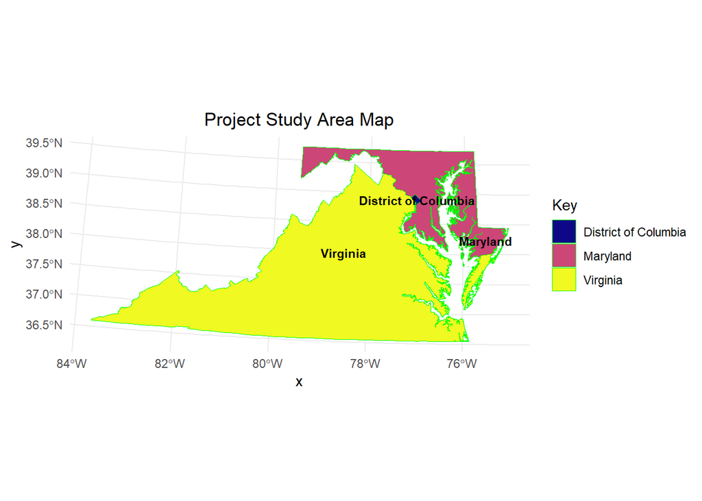

```r
# Transform to NAD83 / UTM Zone 18N (EPSG:26918)
Study_Area <- st_transform(Study_Area, crs = 26918)

# View the structure of the shapefile data
#str(Study_Area)

# Plot the data with labels
library(ggplot2)
library(viridis)

ggplot(data = Study_Area) +
  geom_sf(aes(fill = NAME_1), color = "Green") +  # Fill by NAME_1 and add a border
  geom_sf_text(aes(label = NAME_1), size = 3, check_overlap = TRUE, color = "black", fontface = "bold") +  # Add labels in bold black
  scale_fill_viridis_d(option = "C", name = "Key") +  # Update legend title to "Key"
  theme_minimal() +
  theme(
    plot.title = element_text(hjust = 0.5),  # Center the title
    legend.position = "right"  # Position the legend on the right
  ) +
  ggtitle("Project Study Area Map")
```